# Assignment 5

Mairi-Jo Musgrave, A00407737

15/10/2021

## Article:

Water delivery system effects on coliform bacteria in tap water in First Nations reserves in Manitoba, Canada.

## Reference

Amarawansha, G. E. A., Zvomuya, F., & Farenhorst, A. (2021). Water delivery system effects on coliform bacteria in tap water in First Nations reserves in Manitoba, Canada. Environmental Monitoring and Assessment, 193(6), 1-16.

## Introduction

First nations reserves in Canada experience frequent drinking water advisories due to the presence of coliform bacteria. This article focuses on First Nations reserves in Manitoba, mainly because 50% of homes on these reserves do not have piped water from a water treatment plant, but rather have water brought in from a water treatment plant to local cisterns. Previous studies determined that treated water was more likely to have the presence of coliforms when taken from a cistern than if it had been piped directly from a water treatment plant. This is due to high turbidity in cisterns meaning the chlorine reacts with other chlorine, making it ineffective against microorganisms. Additionally, water can sit in cisterns for a long time before it is used, giving the chlorine more time to decay. This paper looked at three different communities in Manitoba which used different types of cisterns. The objective of this paper was to determine how cisterns affect coliform levels in drinking water in camparison to piped water.

## Methods

Before undertaking any research, members of the research team met with leaders from all three communities to discuss logistics of data collection. A Resolution was drafted and signed by all parties. Members from the community worked with the research team to identify homes in which samples would be collected. For each period of sampling water was collected to test total coliforms and chlorine from the water supply, the water treatment plant, the delivery truck in instances of cistern use, and the tap water in community homes. Ten homes with piped water and ten homes with cistern water were tested. The research team tested two of the communities at three different times to account for temporal differences in water quality. The third community was remote and could therefore only be tested once. In addition to samples collected by the research team, monthly samples of tap water were collected by the community, however these samples varied in number and distribution between communities.

## Results

The study found that samples from the water treatment plant and delivery truck for two communities showed no presence of coliforms, while the water treatment plant and truck samples from the third community showed the presence of coliforms. They also found that chlorine levels from tap water samples in all three communities were lower for samples taken from cisterns compared to those of piped water. They found that 55% of cistern samples had the presence of coliforms, while only 20% of piped water samples had coliforms (Figure 1).

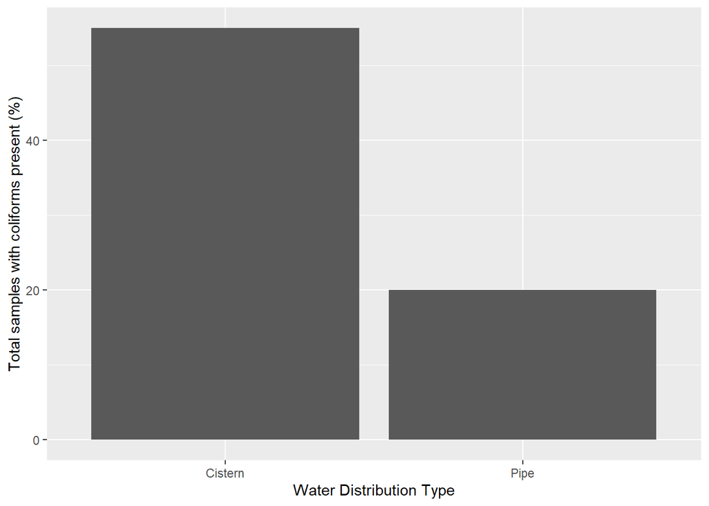

Figure 1: Percentage of water samples from all three communities with presence of coliforms for both cisterns and piped water.

## Conclusion

The research done in this article shows that water from cisterns are more likely to contain the presence of coliforms than piped water. The authors recommend connecting all homes in these communities to the main water line would be the safest course of action.

## GitHub

[Click here](https://github.com/mairijo/ENVS_4826_Assignment_5_Musgrave.git) for GitHub repository